# First Session

Id: 101410 - Asoka Niyonsaba Jean Claude

2025-10-15

Data structure (Vectors, Factors, Lists, Data frame, matrix and arrays) Vector: The foundational R data structure

```r
##Numeric
x <- c(0.5, 0.6)
age<-c(20,35,32,29)
summary(age)
```

```
##    Min. 1st Qu.  Median    Mean 3rd Qu.    Max.
##   20.00   26.75   30.50   29.00   32.75   35.00
```

```r
age<-c(35,24,18,24)
mean(age)
```

```
## [1] 25.25
```

```r
## Logical
x <- c(TRUE, FALSE)
x <- c(T, F)
## Character
x<-c("a","b","c")
class<-c("M","F","F","M")
##Integer
x<-9:29
##Complex
x<-c(1+0i,2+4i)
```

```r
## Matrix and operation within matrices
x<-matrix(1:6,nrow=2,ncol=3)
x
```

```
##      [,1] [,2] [,3]
## [1,]    1    3    5
## [2,]    2    4    6
```

```r
(y<-matrix(1:6,nrow=3,ncol=2))
```

```
##      [,1] [,2]
## [1,]    1    4
## [2,]    2    5
## [3,]    3    6
```

```r
 x%*%y
```

```
##      [,1] [,2]
## [1,]   22   49
## [2,]   28   64
```

```r
## List
x<-list(1,"a",TRUE,1+4i)
x
```

```
## [[1]]
## [1] 1
##
## [[2]]
## [1] "a"
##
## [[3]]
## [1] TRUE
##
## [[4]]
## [1] 1+4i
```

```r
## Factor
x<-factor(c("yes","yes","no","yes","no"))
## Create a vector with NAs init
x<-c(1,2,NA,10,3)
```

```r
## Return a logical vector indicating which elements are NA
is.na(x)
```

```
## [1] FALSE FALSE  TRUE FALSE FALSE
```

```r
x<-c(1,2,4,"NA",5)
bad<-is.na(x)
print(bad)
```

```
## [1] FALSE FALSE FALSE FALSE FALSE
```

What if there are multiple R objects and you want to take the subset with no missing values in any of those objects?

```r
 x<-c(1,2,NA,4,NA,5)
 y<-c("a","b",NA,"d",NA,"f")
 good<-complete.cases(x,y)
 good
```

```
## [1]  TRUE  TRUE FALSE  TRUE FALSE  TRUE
```

Coercion

If character is present,in a vector,R convert everything in the vector to character strings. If a vector only contains logical and numbers,R will convert the logical to numbers, Every true becomes a1,and every FALSE becomes 0

```r
sum(c(TRUE,TRUE,FALSE,FALSE,FALSE))
```

```
## [1] 2
```

Create data Create data Using dataframe Dataframe is more general than matrix How??? Because dataframe can contain different modes of data (Numeric,character and so on)Similar to what you can see in SPSS,SAS,…

```r
### Let’s create a dataframe
studentID<-c(1,2,3,4,5)
math_score<-c(12,17,10,9,NA)
gender<-c("M","F","M","M","F")
it_score<-c(13,18,11,10,19)
scoredata<-data.frame(studentID,gender,math_score,it_score)
scoredata
```

```
##   studentID gender math_score it_score
## 1         1      M         12       13
## 2         2      F         17       18
## 3         3      M         10       11
## 4         4      M          9       10
## 5         5      F         NA       19
```

```r
#View(scoredata)
```

Create data from keyboard Steps1. Create dataframe(or matrix) with variable names2.Invoke the text editor in the data objected created at first step

```r
data_class2<-data.frame(height=numeric(0),weight=numeric(0),bmi=numeric
 (0))
 data_class2<-edit(data_class2)
```

```r
variable.names(women)
```

```
## [1] "height" "weight"
```

```r
head(women)
```

```
##   height weight
## 1     58    115
## 2     59    117
## 3     60    120
## 4     61    123
## 5     62    126
## 6     63    129
```

```r
tail(women)
```

```
##    height weight
## 10     67    142
## 11     68    146
## 12     69    150
## 13     70    154
## 14     71    159
## 15     72    164
```

```r
women[10:20,]
```

```
##      height weight
## 10       67    142
## 11       68    146
## 12       69    150
## 13       70    154
## 14       71    159
## 15       72    164
## NA       NA     NA
## NA.1     NA     NA
## NA.2     NA     NA
## NA.3     NA     NA
## NA.4     NA     NA
```

```r
summary(women$WEIGHT)
```

```
## Length  Class   Mode
##      0   NULL   NULL
```

```r
length(women$WEIGHT)
```

```
## [1] 0
```

```r
women[,-1]
```

```
##  [1] 115 117 120 123 126 129 132 135 139 142 146 150 154 159 164
```

In case you want to use dataset built in R

```r
 data()#listofdatasetscurrentlyavailable
 data("airquality")
 variable.names(airquality)
```

```
## [1] "Ozone"   "Solar.R" "Wind"    "Temp"    "Month"   "Day"
```

```r
 str(airquality)
```

```
## 'data.frame':    153 obs. of  6 variables:
##  $ Ozone  : int  41 36 12 18 NA 28 23 19 8 NA ...
##  $ Solar.R: int  190 118 149 313 NA NA 299 99 19 194 ...
##  $ Wind   : num  7.4 8 12.6 11.5 14.3 14.9 8.6 13.8 20.1 8.6 ...
##  $ Temp   : int  67 72 74 62 56 66 65 59 61 69 ...
##  $ Month  : int  5 5 5 5 5 5 5 5 5 5 ...
##  $ Day    : int  1 2 3 4 5 6 7 8 9 10 ...
```

```r
 summary(airquality)
```

```
##      Ozone           Solar.R           Wind             Temp
##  Min.   :  1.00   Min.   :  7.0   Min.   : 1.700   Min.   :56.00
##  1st Qu.: 18.00   1st Qu.:115.8   1st Qu.: 7.400   1st Qu.:72.00
##  Median : 31.50   Median :205.0   Median : 9.700   Median :79.00
##  Mean   : 42.13   Mean   :185.9   Mean   : 9.958   Mean   :77.88
##  3rd Qu.: 63.25   3rd Qu.:258.8   3rd Qu.:11.500   3rd Qu.:85.00
##  Max.   :168.00   Max.   :334.0   Max.   :20.700   Max.   :97.00
##  NA's   :37       NA's   :7
##      Month            Day
##  Min.   :5.000   Min.   : 1.0
##  1st Qu.:6.000   1st Qu.: 8.0
##  Median :7.000   Median :16.0
##  Mean   :6.993   Mean   :15.8
##  3rd Qu.:8.000   3rd Qu.:23.0
##  Max.   :9.000   Max.   :31.0
##
```

Summary Statistics

```r
summary(women)
```

```
##      height         weight
##  Min.   :58.0   Min.   :115.0
##  1st Qu.:61.5   1st Qu.:124.5
##  Median :65.0   Median :135.0
##  Mean   :65.0   Mean   :136.7
##  3rd Qu.:68.5   3rd Qu.:148.0
##  Max.   :72.0   Max.   :164.0
```

```r
apply(women,2,mean)
```

```
##   height   weight
##  65.0000 136.7333
```

```r
apply(women,2,sd)
```

```
##    height    weight
##  4.472136 15.498694
```

```r
c(mean(women$HEIGHT),sd(women$HEIGHT))
```

```
## [1] NA NA
```

```r
c(mean(women$WEIGHT),sd(women$WEIGHT))
```

```
## [1] NA NA
```

```r
c(Mean=mean(women$HEIGHT),SD=sd(women$HEIGHT))
```

```
## Mean   SD
##   NA   NA
```

```r
c(Mean=mean(women$WEIGHT),SD=sd(women$WEIGHT))
```

```
## Mean   SD
##   NA   NA
```

Variation and covariation using both numerical and graphs Relationship between a categorical and a continuous variable

```r
data("iris")
head(iris)
```

```
##   Sepal.Length Sepal.Width Petal.Length Petal.Width Species
## 1          5.1         3.5          1.4         0.2  setosa
## 2          4.9         3.0          1.4         0.2  setosa
## 3          4.7         3.2          1.3         0.2  setosa
## 4          4.6         3.1          1.5         0.2  setosa
## 5          5.0         3.6          1.4         0.2  setosa
## 6          5.4         3.9          1.7         0.4  setosa
```

```r
mean(iris$Petal.Length)
```

```
## [1] 3.758
```

```r
mean(iris$Petal.Length[iris$Species=="setosa"])
```

```
## [1] 1.462
```

```r
mean(iris$Petal.Length[iris$Species=="versicolor"])
```

```
## [1] 4.26
```

```r
mean(iris$Petal.Length[iris$Species=="virginica"])
```

```
## [1] 5.552
```

```r
#Shortcut
by(iris$Petal.Length,iris$Species,mean)
```

```
## iris$Species: setosa
## [1] 1.462
## ------------------------------------------------------------
## iris$Species: versicolor
## [1] 4.26
## ------------------------------------------------------------
## iris$Species: virginica
## [1] 5.552
```

```r
by(iris$Petal.Length,iris$Species,sd)
```

```
## iris$Species: setosa
## [1] 0.173664
## ------------------------------------------------------------
## iris$Species: versicolor
## [1] 0.469911
## ------------------------------------------------------------
## iris$Species: virginica
## [1] 0.5518947
```

```r
by(iris$Petal.Length,iris$Species,summary)
```

```
## iris$Species: setosa
##    Min. 1st Qu.  Median    Mean 3rd Qu.    Max.
##   1.000   1.400   1.500   1.462   1.575   1.900
## ------------------------------------------------------------
## iris$Species: versicolor
##    Min. 1st Qu.  Median    Mean 3rd Qu.    Max.
##    3.00    4.00    4.35    4.26    4.60    5.10
## ------------------------------------------------------------
## iris$Species: virginica
##    Min. 1st Qu.  Median    Mean 3rd Qu.    Max.
##   4.500   5.100   5.550   5.552   5.875   6.900
```

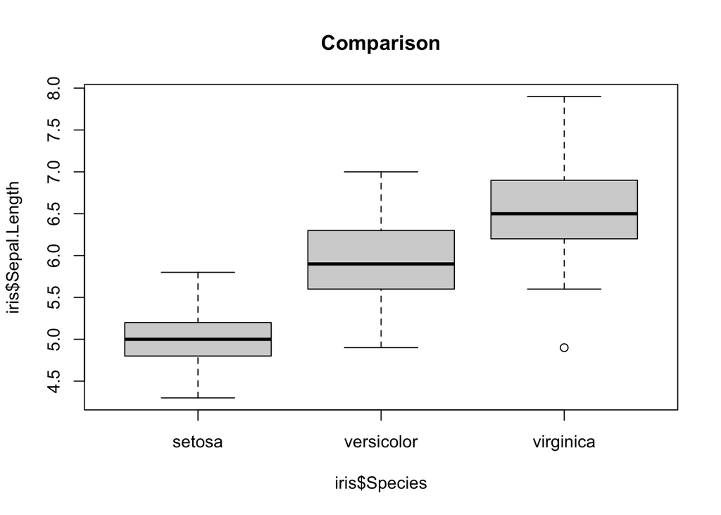

```r
#Visualize the differences in continuous variables between categories using Box-and whisker plot
boxplot(iris$Sepal.Length~iris$Species,data=iris, main="Comparison")
```

Relationship between two categorical variables

```r
ucba<-data.frame(UCBAdmissions)
head(ucba)
```

```
##      Admit Gender Dept Freq
## 1 Admitted   Male    A  512
## 2 Rejected   Male    A  313
## 3 Admitted Female    A   89
## 4 Rejected Female    A   19
## 5 Admitted   Male    B  353
## 6 Rejected   Male    B  207
```

```r
cross<-xtabs(Freq~Gender+Admit,data=ucba)
(cross<-xtabs(Freq~Gender+Admit,data=ucba))
```

```
##         Admit
## Gender   Admitted Rejected
##   Male       1198     1493
##   Female      557     1278
```

```r
##IstheregenderbiasinUCBgraduateadmissionprocess?
 prop.table(cross,2)
```

```
##         Admit
## Gender    Admitted  Rejected
##   Male   0.6826211 0.5387947
##   Female 0.3173789 0.4612053
```

```r
cross2<-xtabs(Freq~Gender+Admit,data=ucba[ucba$Dept=="A",])
 prop.table(cross2,1)
```

```
##         Admit
## Gender    Admitted  Rejected
##   Male   0.6206061 0.3793939
##   Female 0.8240741 0.1759259
```

BarChart

[figure not shown]

```r
dat<-read.table(text="ProdAProdBProdCProdD
 1110506070
 2120508065",header=TRUE)
 barplot(as.matrix(dat),beside=FALSE,col=c("Red","green"))
```

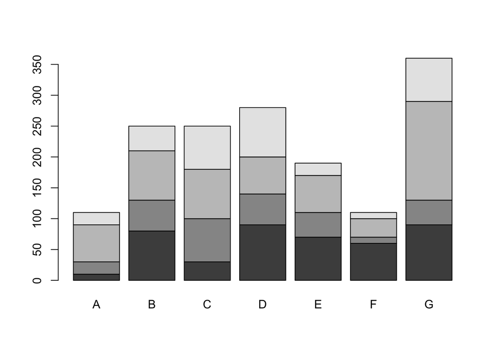

```r
#barplot(as.matrix(dat),beside=TRUE,col=c("gold3","red"))
 dat <- read.table(text = "A B C D E F G
 1 10 80 30 90 70 60 90
 2 20 50 70 50 40 10 40
 3 60 80 80 60 60 30 160
 4 20 40 70 80 20 10 70", header = TRUE)
 barplot(as.matrix(dat))
```

Scatter Plot

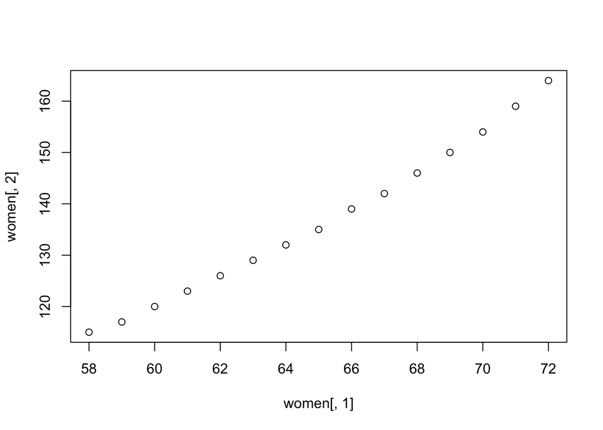

```r
plot(women[,1],women[,2])
```